# Leveraging Relational Databases in R

April 27, 2019

## R as an Extensible Environment

- I/O Interface: csv/txt, json, XML, HTML
- API Connections: httr, URL request, piping
- Remote Integrations: server, cloud computing

## Relational Databases

[figure not shown]

- Commercial or open source software designed to maintain and manage structured data
- Data is stored in logically grouped, disaggregated tables within an interconnected system of relational keys
- Based on relational model based on IBM's Edgar F. Codd
- Mainstay in software and web applications but no traction in data science

## Advantages of Database in Data Science

- Data persistence: historical and current needs
- Data hygiene: adherence to types with less munging/cleaning
- Storage efficiency: normalization reduces repetition of data
- Centralization: multiple user environment and security
- Scalability: not limited to local resources

## Programming Interfaces

[figure not shown]

- Most programming languages support RDBMS connections
- Some languages maintain consistent DB-API specifications and standards:
  - Java: JDBC
  - C++: SQLAPI++
  - NET: ODBC/OLEDB
  - PHP: PDO
  - Python: PEP 249
  - Perl, Ruby, R: DBI

## R DBI Standard

- General: RJDBC, odbc
  - Requires corresponding JDBC/ODBC drivers
- Specific:
  - DBI standard - ROracle, RPostgreSQL, RMySQL, RSQLite

## Use Cases

- CTA with PostgreSQL
- Divvy with IBM DB2
- Metra with SQLite

## Aggregation

```r
library(RPostgreSQL)
library(yaml)

# CONNECT
config = yaml.load_file("dbconfig.yaml")
conn <- dbConnect(RPostgreSQL::PostgreSQL(), host=config$pg_conn$host, dbname=config$pg_conn$name,
                  user=config$pg_conn$user, password=config$pg_conn$pwd, port=config$pg_conn$port)

# R AGGREGATION (MULTIPLE FUNCS)
# do.call(data.frame,
#        aggregate(rides ~ route + routename, agg_csv,
#                  function(x) c(count=length(x), sum=sum(x), mean=mean(x),
#                                median=median(x), min=min(x), max=max(x))))

# POSTGRES AGGREGATION
sql <- 'SELECT rt.route_name,
               COUNT(rd.rides) AS "count",
               SUM(rd.rides) AS "sum",
               AVG(rd.rides) AS "mean",
               MEDIAN(rd.rides) AS "median",
               R_MEDIAN(rd.rides) AS "r_median",
               MIN(rd.rides) AS "min",
               MAX(rd.rides) AS "max"
        FROM bus_routes rt
        INNER JOIN bus_rides rd ON rt.route_id = rd.route_id
        GROUP BY rt.route_name
        ORDER BY SUM(rd.rides) DESC
        LIMIT 10'

agg_sql <- dbGetQuery(conn, sql)

knitr::kable(agg_sql)
```

| route_name | count | sum | mean | median | r_median | min | max |
| --- | --- | --- | --- | --- | --- | --- | --- |
| 79th | 6390 | 173636975 | 27173.24 | 27834.5 | 27834.5 | 7896 | 43081 |
| Ashland | 6390 | 154149367 | 24123.53 | 23886.5 | 23886.5 | 5570 | 45177 |
| Chicago | 6390 | 128229988 | 20067.29 | 21764.0 | 21764.0 | 4448 | 35893 |
| Western | 6390 | 127486748 | 19950.98 | 19699.0 | 19699.0 | 4985 | 37202 |
| Cottage Grove | 6390 | 126872609 | 19854.87 | 21264.5 | 21264.5 | 5489 | 31187 |
| Belmont | 6390 | 121019567 | 18938.90 | 20777.5 | 20777.5 | 3451 | 30025 |
| Clark | 6390 | 117682897 | 18416.73 | 19270.5 | 19270.5 | 3310 | 26896 |
| King Drive | 6390 | 117268860 | 18351.93 | 19560.5 | 19560.5 | 3993 | 29896 |
| Sheridan | 6390 | 116432271 | 18221.01 | 18956.0 | 18956.0 | 2666 | 33236 |
| Halsted | 6390 | 116168600 | 18179.75 | 19331.0 | 19331.0 | 2915 | 30605 |

### Graphing

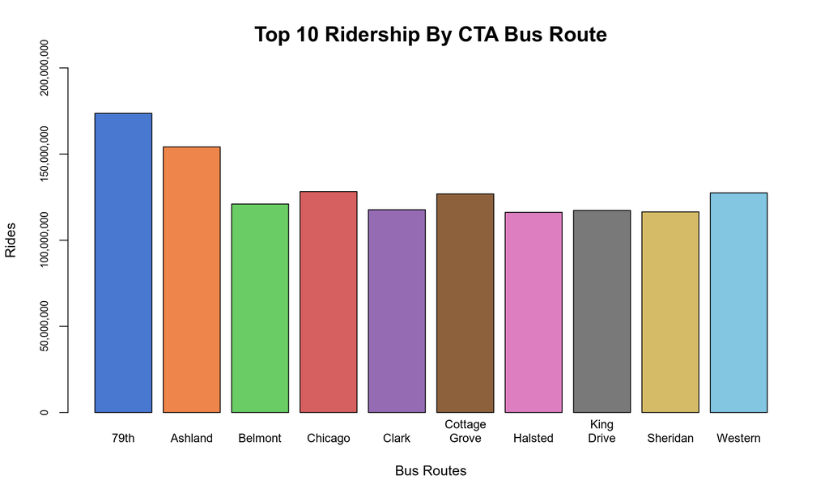

## Aggregation

| year | rail_line | rail_total |
| --- | --- | --- |
| 2001 | blue | 33723000.0 |
| 2002 | blue | 34061468.7 |
| 2003 | blue | 34118073.5 |
| 2004 | blue | 34586710.0 |
| 2005 | blue | 36277366.0 |
| 2006 | blue | 36988998.7 |
| 2007 | blue | 34996201.2 |
| 2008 | blue | 37294108.7 |
| 2009 | blue | 35671459.8 |
| 2010 | blue | 38217125.3 |
| 2011 | blue | 41819469.5 |
| 2012 | blue | 44069757.2 |
| 2013 | blue | 45304180.5 |
| 2014 | blue | 45876383.5 |
| 2015 | blue | 47754470.5 |
| 2016 | blue | 47211306.3 |
| 2017 | blue | 46113140.5 |
| 2018 | blue | 22176147.5 |
| 2001 | brown | 15638940.9 |
| 2002 | brown | 15513075.9 |
| 2003 | brown | 15426019.5 |
| 2004 | brown | 14999639.5 |
| 2005 | brown | 15526814.5 |
| 2006 | brown | 15900764.1 |
| 2007 | brown | 15158711.8 |
| 2008 | brown | 15867834.6 |
| 2009 | brown | 17423540.3 |
| 2010 | brown | 18312314.3 |
| 2011 | brown | 19697790.5 |
| 2012 | brown | 20542951.0 |

[output cut: 132 more lines]

### Graphing

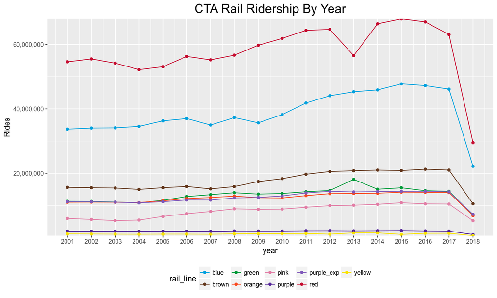

### Modeling

```
##   id station_id       station_name  ride_date day_type raw rides season
## 1  1      40010 Austin-Forest Park 2001-01-01        U 290   290 winter
## 2  2      40020        Harlem-Lake 2001-01-01        U 633   633 winter
## 3  3      40030       Pulaski-Lake 2001-01-01        U 483   483 winter
## 4  4      40040       Quincy/Wells 2001-01-01        U 374    93 winter
## 5  4      40040       Quincy/Wells 2001-01-01        U 374    93 winter
## 6  4      40040       Quincy/Wells 2001-01-01        U 374    93 winter
##   latitude longitude rail_line ada direction ue_rate gas_price avg_temp
## 1 41.87085 -87.77681      blue   0     W | E     5.3     1.487     14.5
## 2 41.88685 -87.80318     green   1     E | W     5.3     1.487     14.5
## 3 41.88541 -87.72540     green   1     W | E     5.3     1.487     14.5
## 4 41.87872 -87.63374     brown   0         S     5.3     1.487     14.5
## 5 41.87872 -87.63374    orange   0         N     5.3     1.487     14.5
## 6 41.87872 -87.63374      pink   0         N     5.3     1.487     14.5
##   precipitation snow_depth
## 1             0         17
## 2             0         17
## 3             0         17
## 4             0         17
## 5             0         17
## 6             0         17
```

```
##
## Call:
## lm(formula = rides ~ day_type + season + latitude + longitude +
##     rail_line + ue_rate + gas_price + avg_temp + precipitation +
##     snow_depth, data = rail_model_data)
##
## Residuals:
##     Min      1Q  Median      3Q     Max
## -6249.5  -932.9  -256.2   536.9 30570.4
##
## Coefficients:
##                        Estimate  Std. Error  t value             Pr(>|t|)
## (Intercept)         -68149.8607   3556.3642  -19.163 < 0.0000000000000002
## day_typeU             -454.4689      6.6549  -68.290 < 0.0000000000000002
## day_typeW             1157.9025      5.2941  218.717 < 0.0000000000000002
## seasonspring          -177.8150      5.3603  -33.172 < 0.0000000000000002
## seasonsummer          -185.4726      6.6439  -27.916 < 0.0000000000000002
## seasonwinter          -160.7995      6.1740  -26.044 < 0.0000000000000002
## latitude             -3995.1405     36.6987 -108.863 < 0.0000000000000002
## longitude            -2708.3027     43.8227  -61.801 < 0.0000000000000002
## rail_linebrown       -1180.4292      7.2371 -163.109 < 0.0000000000000002
## rail_linegreen       -2069.6169      6.8682 -301.334 < 0.0000000000000002
## rail_lineorange      -1077.4023      8.3213 -129.476 < 0.0000000000000002
## rail_linepink        -2211.5330      7.3945 -299.076 < 0.0000000000000002
## rail_linepurple      -2027.3643     11.1919 -181.146 < 0.0000000000000002
## rail_linepurple_exp  -1547.6652      7.6936 -201.163 < 0.0000000000000002
## rail_linered          1641.3142      6.9360  236.637 < 0.0000000000000002
## rail_lineyellow      -1400.4416     17.6707  -79.252 < 0.0000000000000002
## ue_rate                 -5.3018      0.9843   -5.387         0.0000000718
## gas_price              185.5411      2.4399   76.046 < 0.0000000000000002
## avg_temp                 5.0833      0.1659   30.635 < 0.0000000000000002
## precipitation          -83.1416      5.2864  -15.727 < 0.0000000000000002
## snow_depth               1.6746      1.2015    1.394                0.163
##
## (Intercept)         ***
## day_typeU           ***
## day_typeW           ***
## seasonspring        ***
## seasonsummer        ***
## seasonwinter        ***
## latitude            ***
## longitude           ***
## rail_linebrown      ***
## rail_linegreen      ***
## rail_lineorange     ***
## rail_linepink       ***
## rail_linepurple     ***
## rail_linepurple_exp ***
## rail_linered        ***
## rail_lineyellow     ***
## ue_rate             ***
## gas_price           ***
## avg_temp            ***
## precipitation       ***
## snow_depth
## ---
## Signif. codes:  0 '***' 0.001 '**' 0.01 '*' 0.05 '.' 0.1 ' ' 1
##
## Residual standard error: 1850 on 1021214 degrees of freedom
##   (209365 observations deleted due to missingness)
## Multiple R-squared:  0.4031, Adjusted R-squared:  0.4031
## F-statistic: 3.449e+04 on 20 and 1021214 DF,  p-value: < 0.00000000000000022
```

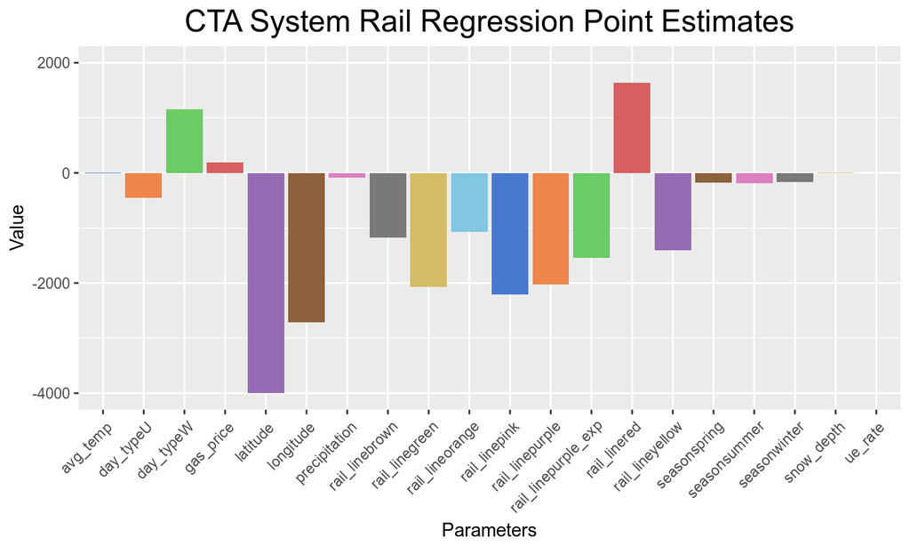

```
## [1] TRUE
```

## Calculation

```
## [
##   {
##     "FROM_STATION_ID": 76,
##     "FROM_STATION_NAME": "Lake Shore Dr & Monroe St",
##     "FROM_LATITUDE": 41.881,
##     "FROM_LONGITUDE": -87.6167,
##     "TOTAL_DURATION": 444455108
##   },
##   {
##     "FROM_STATION_ID": 35,
##     "FROM_STATION_NAME": "Streeter Dr & Grand Ave",
##     "FROM_LATITUDE": 41.8923,
##     "FROM_LONGITUDE": -87.612,
##     "TOTAL_DURATION": 431638473
##   },
##   {
##     "FROM_STATION_ID": 85,
##     "FROM_STATION_NAME": "Michigan Ave & Oak St",
##     "FROM_LATITUDE": 41.901,
##     "FROM_LONGITUDE": -87.6238,
##     "TOTAL_DURATION": 351053592
##   },
##   {
##     "FROM_STATION_ID": 90,
##     "FROM_STATION_NAME": "Millennium Park",
##     "FROM_LATITUDE": 41.881,
##     "FROM_LONGITUDE": -87.6241,
##     "TOTAL_DURATION": 347331136
##   },
##   {
##     "FROM_STATION_ID": 177,
##     "FROM_STATION_NAME": "Theater on the Lake",
##     "FROM_LATITUDE": 41.9263,
##     "FROM_LONGITUDE": -87.6308,
##     "TOTAL_DURATION": 330660276
##   },
##   {
##     "FROM_STATION_ID": 268,
##     "FROM_STATION_NAME": "Lake Shore Dr & North Blvd",
##     "FROM_LATITUDE": 41.9117,
```

[output cut: 17 more lines]

```
##   {
##     "FROM_STATION_ID": 43,
##     "FROM_STATION_NAME": "Michigan Ave & Washington St",
##     "FROM_LATITUDE": 41.8839,
##     "FROM_LONGITUDE": -87.6246,
##     "TOTAL_DURATION": 179427697
##   },
##   {
##     "FROM_STATION_ID": 3,
##     "FROM_STATION_NAME": "Shedd Aquarium",
##     "FROM_LATITUDE": 41.8672,
##     "FROM_LONGITUDE": -87.6154,
##     "TOTAL_DURATION": 178996820
##   }
## ]
```

```
## [
##   {
##     "TO_STATION_ID": 35,
##     "TO_STATION_NAME": "Streeter Dr & Grand Ave",
##     "TO_LATITUDE": 41.8923,
##     "TO_LONGITUDE": -87.612,
##     "TOTAL_DURATION": 469992965
##   },
##   {
##     "TO_STATION_ID": 76,
##     "TO_STATION_NAME": "Lake Shore Dr & Monroe St",
##     "TO_LATITUDE": 41.881,
##     "TO_LONGITUDE": -87.6167,
##     "TOTAL_DURATION": 396754905
##   },
##   {
##     "TO_STATION_ID": 177,
##     "TO_STATION_NAME": "Theater on the Lake",
##     "TO_LATITUDE": 41.9263,
##     "TO_LONGITUDE": -87.6308,
##     "TOTAL_DURATION": 370722559
##   },
##   {
##     "TO_STATION_ID": 85,
##     "TO_STATION_NAME": "Michigan Ave & Oak St",
##     "TO_LATITUDE": 41.901,
##     "TO_LONGITUDE": -87.6238,
##     "TOTAL_DURATION": 369016876
##   },
##   {
##     "TO_STATION_ID": 90,
##     "TO_STATION_NAME": "Millennium Park",
##     "TO_LATITUDE": 41.881,
##     "TO_LONGITUDE": -87.6241,
##     "TOTAL_DURATION": 344723608
##   },
##   {
##     "TO_STATION_ID": 268,
##     "TO_STATION_NAME": "Lake Shore Dr & North Blvd",
##     "TO_LATITUDE": 41.9117,
```

[output cut: 15 more lines]

```
##   {
##     "TO_STATION_ID": 43,
##     "TO_STATION_NAME": "Michigan Ave & Washington St",
##     "TO_LATITUDE": 41.8839,
##     "TO_LONGITUDE": -87.6246,
##     "TOTAL_DURATION": 158901379
##   },
##   {
##     "TO_STATION_ID": 3,
##     "TO_STATION_NAME": "Shedd Aquarium",
##     "TO_LATITUDE": 41.8672,
##     "TO_LONGITUDE": -87.6154,
##     "TOTAL_DURATION": 158356779
##   }
## ]
```

[figure not shown]

```r
# DISCONNECT FROM DATABASE
dbDisconnect(conn)
```